# PD3

Witold Merkel

20 11 2019

# Funkcje zmieniające standardowe funkcje na *NSE*

Funkcje *NSE* będę tworzył na dwa sposoby różne, aby porównać ich szybkość. Dwa te sposoby różnią się tylko metodą wyciągania parametrów, sprawdzimy w tej pracy domowej czy ma to wpływ na ich działanie, a jeżeli ma to jak duży. Szybkość działania funkcji porównamy mikrobenchmarkami. Poniżej zamiszczam kod tych funkcji zmieniających na nse oraz przygotowanie pozostalych funkcji oraz duże i małe dane. Jedne dane są ponad 5 razy większe niż drugie, może dalej nie są duże, ale są wystarczająco dużo, aby różnica była zauważalna.

```r
do_nse_1 <- function(funkcjon) {
  function(data, ...) {
    argument_list <- as.list(substitute(list(...)))[-1]
    argument_vals <- lapply(argument_list, function(x) {
      eval(x, data)
    })
    do.call(funkcjon, argument_vals)
  }
}

do_nse_2 <- function(funkcjon) {
  function(data, ...) {
    argument_list <- match.call(expand.dots = FALSE)$`...`
    argument_vals <- lapply(argument_list, function(x) {
      eval(x, data)
    })
    do.call(funkcjon, argument_vals)
  }
}

min_nse1 <- do_nse_1(min)
min_nse2 <- do_nse_2(min)

mean_nse1 <- do_nse_1(mean)
mean_nse2 <- do_nse_2(mean)

unlist_nse1 <- do_nse_1(unlist)
unlist_nse2 <- do_nse_2(unlist)

lm_nse1 <- do_nse_1(lm)
lm_nse2 <- do_nse_2(lm)

max_nse1 <- do_nse_1(max)
max_nse2 <- do_nse_2(max)

small_data <- Puromycin
big_data <- DNase
```

# Porównanie dla różnych rozmiarów danych i różnych wywołań funkcji

W tej sekcji dokonamy porównania dla różnych parametrów

## Małe dane

Najpierw przyjżymy się małej ramce danych i każdej funcji po kolei.

### **min**

Idąc kolejnościa ż treści zadania domowego najpierw sprawdźmy znajdowanie minimum.

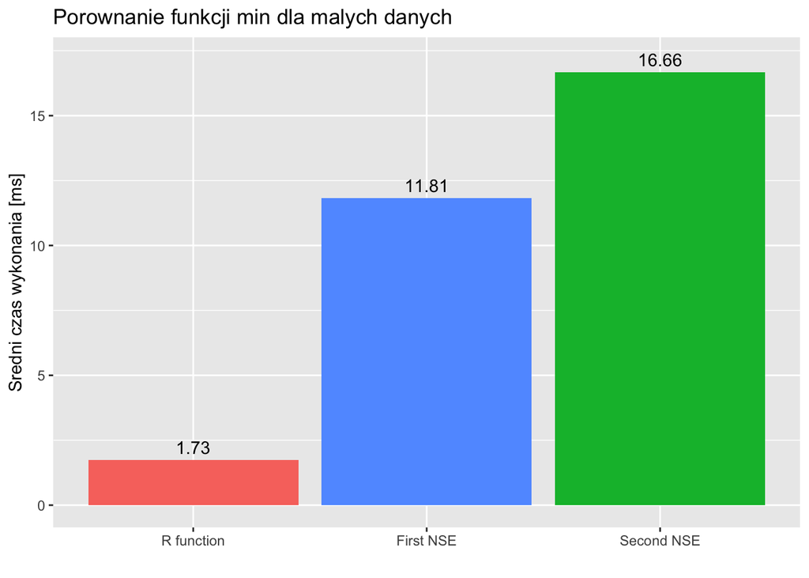

```r
min_results <- summary(microbenchmark::microbenchmark(
  "R function" = min(small_data$conc),
  "First NSE" = min_nse1(small_data, conc),
  "Second NSE" = min_nse2(small_data, conc),
  unit = 'us'
))[, c('expr', 'mean')]

ggplot(data = min_results) +
  geom_col(aes(x = expr, y = mean, fill = c("blue", "red", "green"))) +
  labs(y = "Sredni czas wykonania [ms]", x = "", title = "Porownanie funkcji min dla malych danych") + theme(legend.position = 0)+
  geom_text(aes(label = as.character(round(mean, 2)), y = as.numeric(mean) + 0.5, x = expr))
```

### **mean**

Naturalnie teraz sprawdzmy mean, zrobimy to dla innej kolumny.

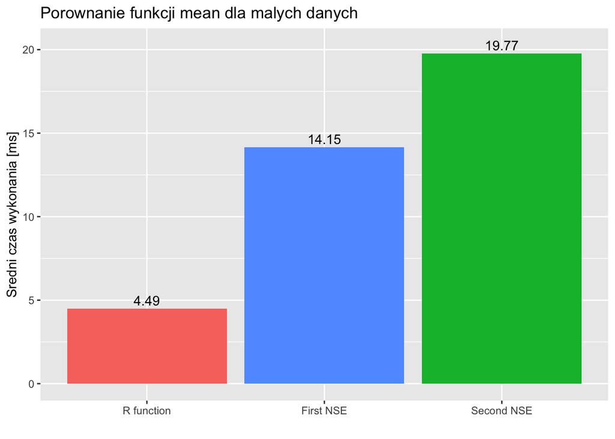

```r
mean_results <- summary(microbenchmark::microbenchmark(
  "R function" = mean(small_data$rate),
  "First NSE" = mean_nse1(small_data, rate),
  "Second NSE" = mean_nse2(small_data, rate),
  unit = 'us'
))[, c('expr', 'mean')]

ggplot(data = mean_results) +
  geom_col(aes(x = expr, y = mean, fill = c("blue", "red", "green"))) +
  labs(y = "Sredni czas wykonania [ms]", x = "", title = "Porownanie funkcji mean dla malych danych") + theme(legend.position = 0) +
  geom_text(aes(label = as.character(round(mean, 2)), y = as.numeric(mean) + 0.5, x = expr))
```

### **unlist** z use.names = TRUE

Kolejny podpunkt z listy.

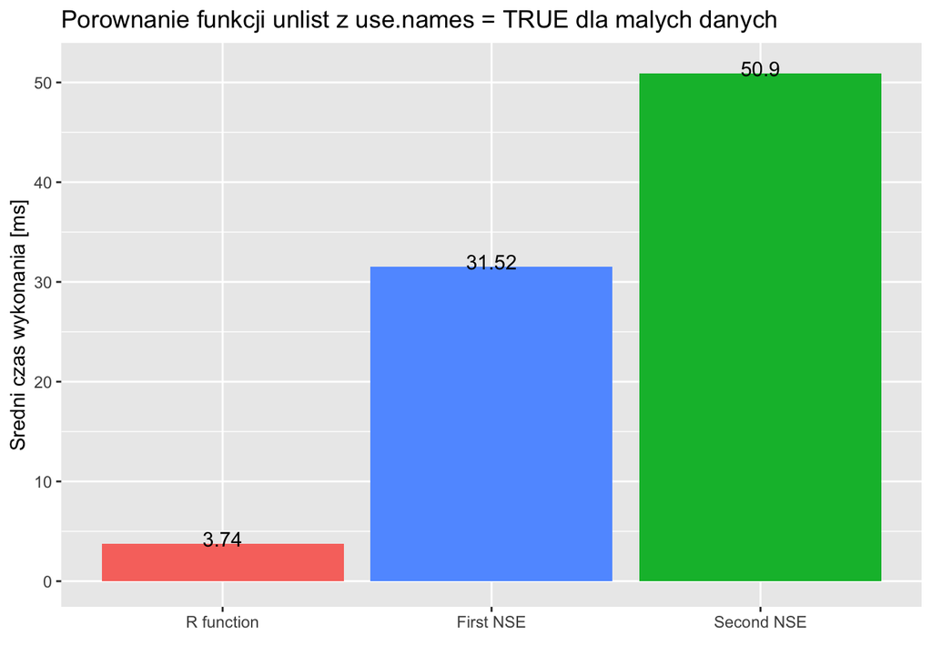

```r
small_list <- split(small_data, seq(nrow(small_data)))
unlist_t_results <- summary(microbenchmark::microbenchmark(
  "R function" = unlist(small_list$`1`, use.names = TRUE),
  "First NSE" = unlist_nse1(small_list, `1`, use.names = TRUE),
  "Second NSE" = unlist_nse2(small_list, `1`, use.names = TRUE),
  unit = 'us'
))[, c('expr', 'mean')]

ggplot(data = unlist_t_results) +
  geom_col(aes(x = expr, y = mean, fill = c("blue", "red", "green"))) +
  labs(y = "Sredni czas wykonania [ms]", x = "", title = "Porownanie funkcji unlist z use.names = TRUE dla malych danych") +
  theme(legend.position = 0) +
  geom_text(aes(label = as.character(round(mean, 2)), y = as.numeric(mean) + 0.5, x = expr))
```

### **unlist** z use.names = FALSE

I następny.

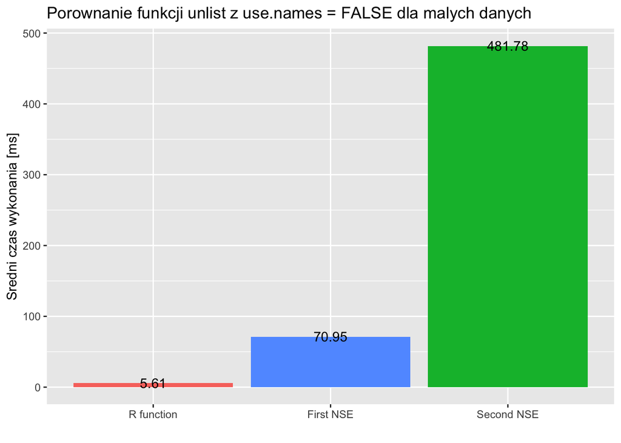

```r
unlist_f_results <- summary(microbenchmark::microbenchmark(
  "R function" = unlist(small_list$`1`, use.names = FALSE),
  "First NSE" = unlist_nse1(small_list, `1`, use.names = FALSE),
  "Second NSE" = unlist_nse2(small_list, `1`, use.names = FALSE),
  unit = 'us'
))[, c('expr', 'mean')]

ggplot(data = unlist_f_results) +
  geom_col(aes(x = expr, y = mean, fill = c("blue", "red", "green"))) +
  labs(y = "Sredni czas wykonania [ms]", x = "", title = "Porownanie funkcji unlist z use.names = FALSE dla malych danych") +
  theme(legend.position = 0) +
  geom_text(aes(label = as.character(round(mean, 2)), y = as.numeric(mean) + 0.5, x = expr))
```

### **lm**

Kolejny.

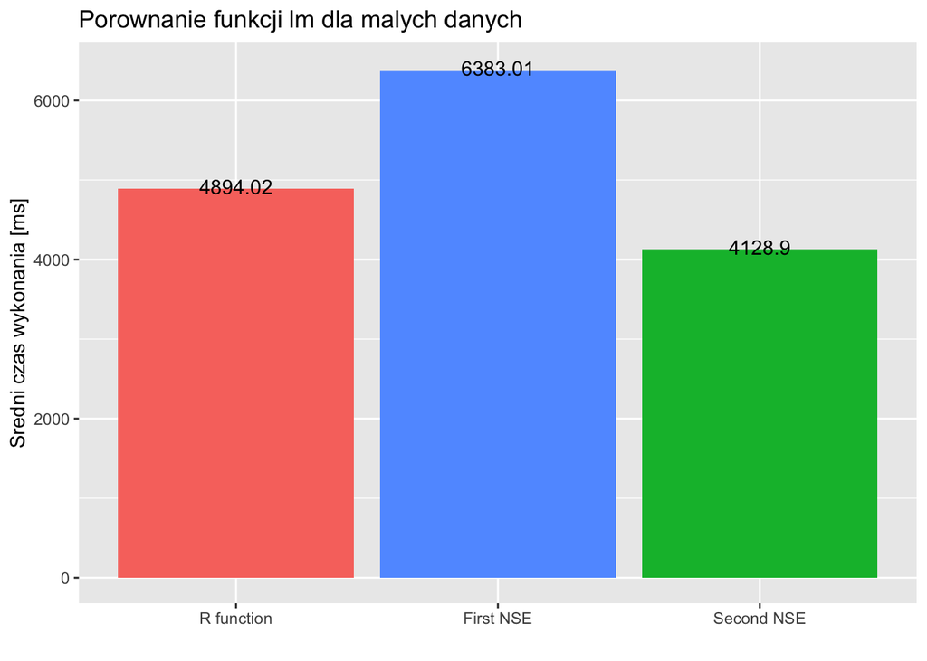

```r
lm_results <- summary(microbenchmark::microbenchmark(
  "R function" = lm(conc ~ rate + state, data = small_data),
  "First NSE" = lm_nse1(small_data, conc ~ rate + state),
  "Second NSE" = lm_nse2(small_data, conc ~ rate + state),
  unit = 'us'
))[, c('expr', 'mean')]

ggplot(data = lm_results) +
  geom_col(aes(x = expr, y = mean, fill = c("blue", "red", "green"))) +
  labs(y = "Sredni czas wykonania [ms]", x = "", title = "Porownanie funkcji lm dla malych danych") +
  theme(legend.position = 0) +
  geom_text(aes(label = as.character(round(mean, 2)), y = as.numeric(mean) + 25, x = expr))
```

### **max**

Tu poszalejemy i wyjdziemy poza podstawowe wymagania i sprawdzimy jeszcze zachowanie dla funkcjij *max*.

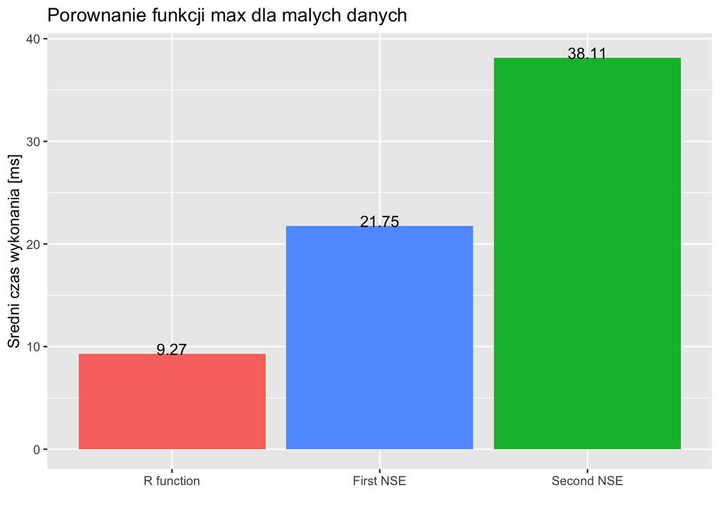

```r
max_results <- summary(microbenchmark::microbenchmark(
  "R function" = max(small_data$conc),
  "First NSE" = max_nse1(small_data, conc),
  "Second NSE" = max_nse2(small_data, conc),
  unit = 'us'
))[, c('expr', 'mean')]

ggplot(data = max_results) +
  geom_col(aes(x = expr, y = mean, fill = c("blue", "red", "green"))) +
  labs(y = "Sredni czas wykonania [ms]", x = "", title = "Porownanie funkcji max dla malych danych") + theme(legend.position = 0)+
  geom_text(aes(label = as.character(round(mean, 2)), y = as.numeric(mean) + 0.5, x = expr))
```

## Duże dane

Teraz przyjrzymy się większej ramce danych i każdej funcji po kolei.

### **min**

Idąc kolejnościa ż treści zadania domowego najpierw sprawdźmy znajdowanie minimum.

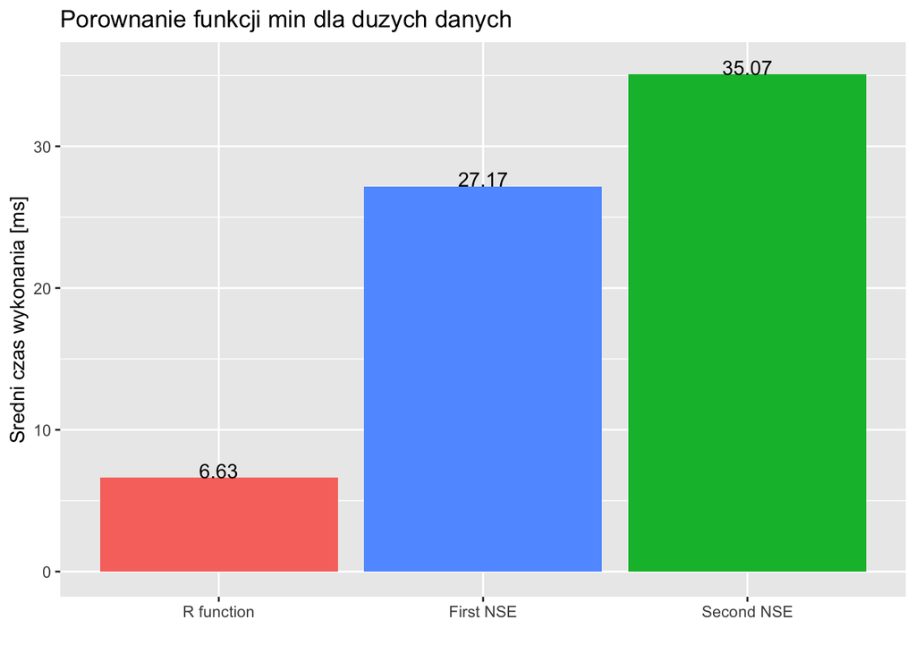

```r
min_results <- summary(microbenchmark::microbenchmark(
  "R function" = min(big_data$conc),
  "First NSE" = min_nse1(big_data, conc),
  "Second NSE" = min_nse2(big_data, conc),
  unit = 'us'
))[, c('expr', 'mean')]

ggplot(data = min_results) +
  geom_col(aes(x = expr, y = mean, fill = c("blue", "red", "green"))) +
  labs(y = "Sredni czas wykonania [ms]", x = "", title = "Porownanie funkcji min dla duzych danych") + theme(legend.position = 0)+
  geom_text(aes(label = as.character(round(mean, 2)), y = as.numeric(mean) + 0.5, x = expr))
```

### **mean**

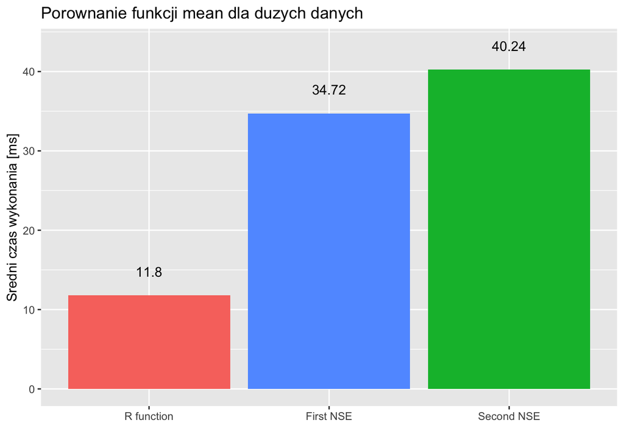

```r
mean_results <- summary(microbenchmark::microbenchmark(
  "R function" = mean(big_data$conc),
  "First NSE" = mean_nse1(big_data, conc),
  "Second NSE" = mean_nse2(big_data, conc),
  unit = 'us'
))[, c('expr', 'mean')]

ggplot(data = mean_results) +
  geom_col(aes(x = expr, y = mean, fill = c("blue", "red", "green"))) +
  labs(y = "Sredni czas wykonania [ms]", x = "", title = "Porownanie funkcji mean dla duzych danych") + theme(legend.position = 0) +
  geom_text(aes(label = as.character(round(mean, 2)), y = as.numeric(mean) + 3, x = expr))
```

### **unlist** z use.names = TRUE

Kolejny podpunkt z listy.

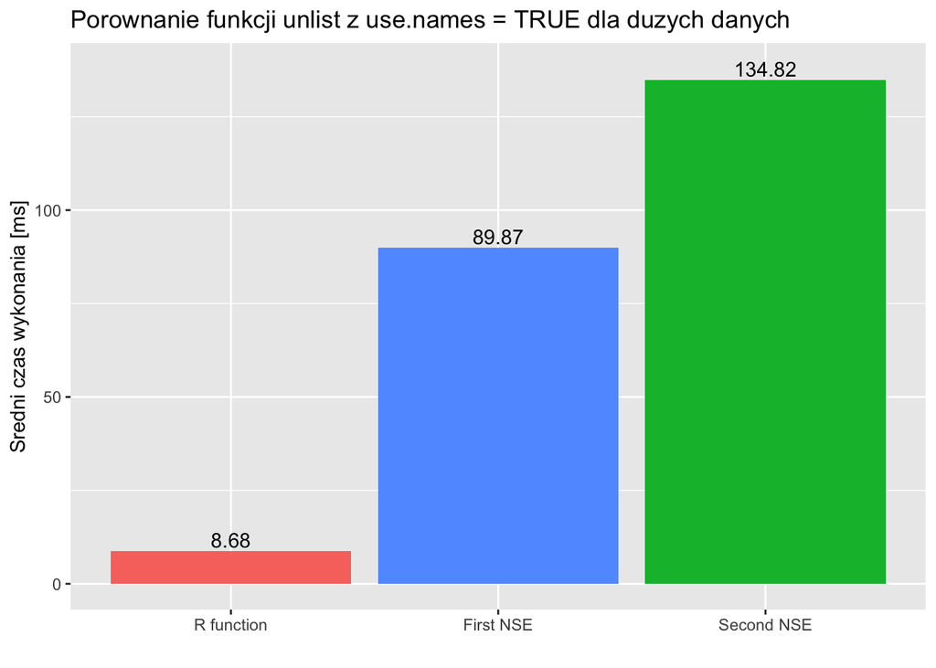

```r
big_list <- split(big_data, seq(nrow(big_data)))
unlist_t_results <- summary(microbenchmark::microbenchmark(
  "R function" = unlist(big_list$`1`, use.names = TRUE),
  "First NSE" = unlist_nse1(big_list, `1`, use.names = TRUE),
  "Second NSE" = unlist_nse2(big_list, `1`, use.names = TRUE),
  unit = 'us'
))[, c('expr', 'mean')]

ggplot(data = unlist_t_results) +
  geom_col(aes(x = expr, y = mean, fill = c("blue", "red", "green"))) +
  labs(y = "Sredni czas wykonania [ms]", x = "", title = "Porownanie funkcji unlist z use.names = TRUE dla duzych danych") +
  theme(legend.position = 0) +
  geom_text(aes(label = as.character(round(mean, 2)), y = as.numeric(mean) + 3, x = expr))
```

### **unlist** z use.names = FALSE

I następny.

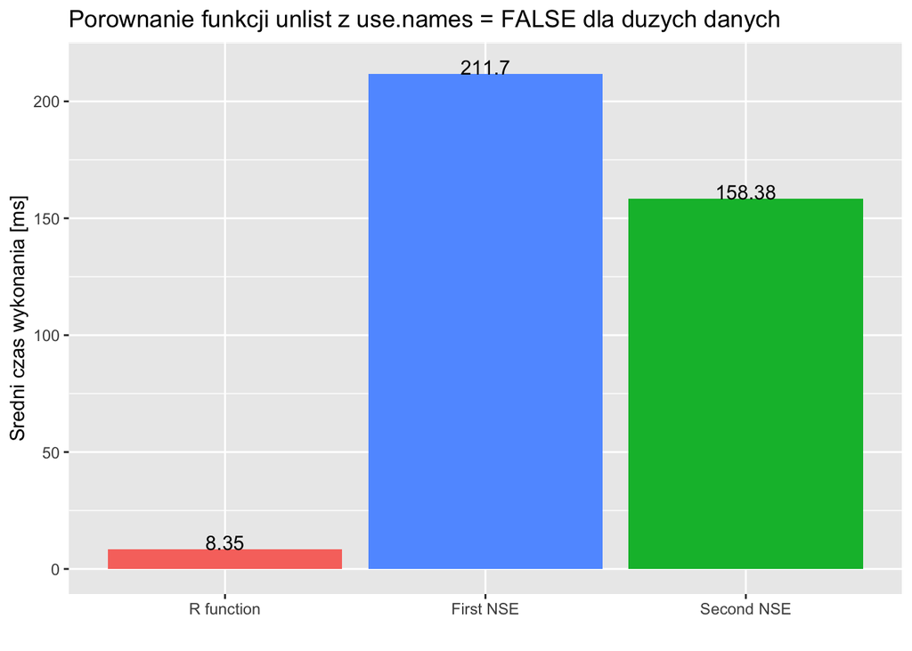

```r
unlist_f_results <- summary(microbenchmark::microbenchmark(
  "R function" = unlist(big_list$`1`, use.names = FALSE),
  "First NSE" = unlist_nse1(big_list, `1`, use.names = FALSE),
  "Second NSE" = unlist_nse2(big_list, `1`, use.names = FALSE),
  unit = 'us'
))[, c('expr', 'mean')]

ggplot(data = unlist_f_results) +
  geom_col(aes(x = expr, y = mean, fill = c("blue", "red", "green"))) +
  labs(y = "Sredni czas wykonania [ms]", x = "", title = "Porownanie funkcji unlist z use.names = FALSE dla duzych danych") +
  theme(legend.position = 0) +
  geom_text(aes(label = as.character(round(mean, 2)), y = as.numeric(mean) + 3, x = expr))
```

### **lm**

Kolejny.

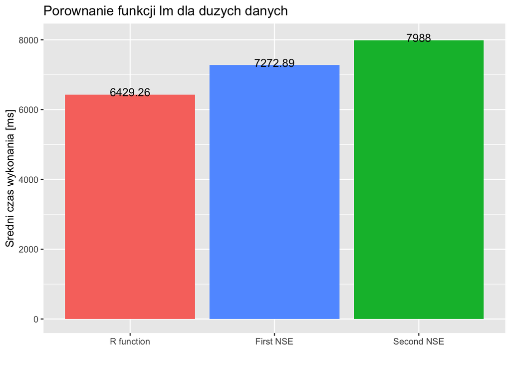

```r
lm_results <- summary(microbenchmark::microbenchmark(
  "R function" = lm(density ~ conc + Run, data = big_data),
  "First NSE" = lm_nse1(big_data, density ~ conc + Run),
  "Second NSE" = lm_nse2(big_data, density ~ conc + Run),
  unit = 'us'
))[, c('expr', 'mean')]

ggplot(data = lm_results) +
  geom_col(aes(x = expr, y = mean, fill = c("blue", "red", "green"))) +
  labs(y = "Sredni czas wykonania [ms]", x = "", title = "Porownanie funkcji lm dla duzych danych") +
  theme(legend.position = 0) +
  geom_text(aes(label = as.character(round(mean, 2)), y = as.numeric(mean) + 75, x = expr))
```

### **max**

Tu poszalejemy i wyjdziemy poza podstawowe wymagania i sprawdzimy jeszcze zachowanie dla funkcjij *max*.

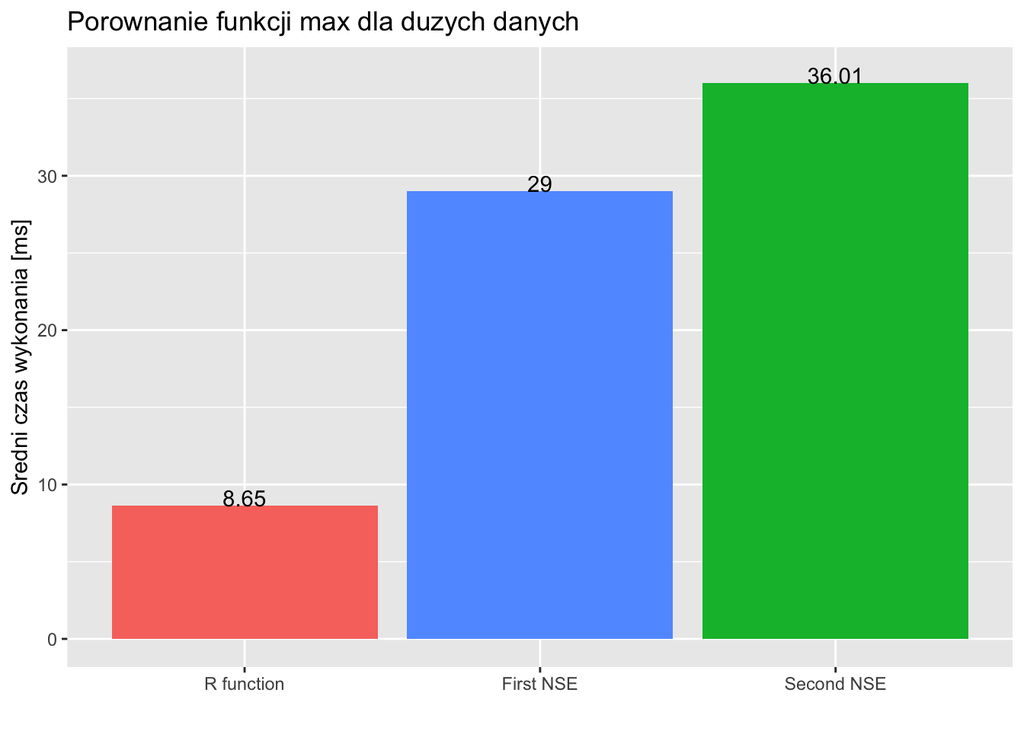

```r
max_results <- summary(microbenchmark::microbenchmark(
  "R function" = max(big_data$conc),
  "First NSE" = max_nse1(big_data, conc),
  "Second NSE" = max_nse2(big_data, conc),
  unit = 'us'
))[, c('expr', 'mean')]

ggplot(data = max_results) +
  geom_col(aes(x = expr, y = mean, fill = c("blue", "red", "green"))) +
  labs(y = "Sredni czas wykonania [ms]", x = "", title = "Porownanie funkcji max dla duzych danych") + theme(legend.position = 0)+
  geom_text(aes(label = as.character(round(mean, 2)), y = as.numeric(mean) + 0.5, x = expr))
```

# Podsumowanie

Widzimy, że tak napisane funkcje są zdecydowanie wolniejsze od tych napisanych przez świetnych deweloperów R’a. Jedyny przykład kiedy fukncje są konkurencyjne pod względem szybkości są warianty funkcji *lm*. W porównaniu funkcje NSE mają podobne osiągi, raz jedna jest szybsza, a raz druga.